# Fat Data Matrices and False Positives

Pietro Franceschi | pietro.franceschi@fmach.it

## Intro

This demo deals with “random organization”. As we discussed in the lecture, an experiment is always performed on a subset of the population, so a measured “organization”

- can mirror a population level property
- can be the result of an “unlucky” sampling

To understand the second point, just consider a hypothetical sampling of the human population made by an extraterrestrial entity. If it randomly samples a couple of humans, it could well conclude that we all come from the same country!

## A dummy experiment

Let’s make a more scientific example. Let’s create a fake metabolomics experiment (but it can be anything you like …) where I’m measuring 1000 **independent** variables on a group of samples. And let’s suppose that I want to study the correlation between the different variables to infer new regulatory networks …

To simulate my dummy experiment I fill my data matrices with random numbers. To show the role of the sample/variable ratio, I simulate five scenarios with a growing number of samples

```r
## random "expression" data matrices: samples in rows, 1000 variables in columns
dummy_data <- tibble(nsamples = c(10, 30, 100, 300, 500)) |>
  mutate(DM = map(nsamples, \(x) matrix(rnorm(1000 * x), ncol = 1000)))

dummy_data
```

```
## # A tibble: 5 × 2
##   nsamples DM
##      <dbl> <list>
## 1       10 <dbl [10 × 1,000]>
## 2       30 <dbl [30 × 1,000]>
## 3      100 <dbl [100 × 1,000]>
## 4      300 <dbl [300 × 1,000]>
## 5      500 <dbl [500 × 1,000]>
```

That’s the battery of data matrices of growing size. Do I have some “true” results inside my data?

**NO!**

## Correlation matrices

OK, let’s calculate the correlation among the different variables in all the 5 scenarios

```r
dummy_data <- dummy_data |>
  mutate(varCorr = map(DM, cor))
```

Just to see what’s going on, let’s have a look at one of the correlation matrices (30 samples), actually only at the first 100 variables

```r
dim(dummy_data$varCorr[[2]])
```

```
## [1] 1000 1000
```

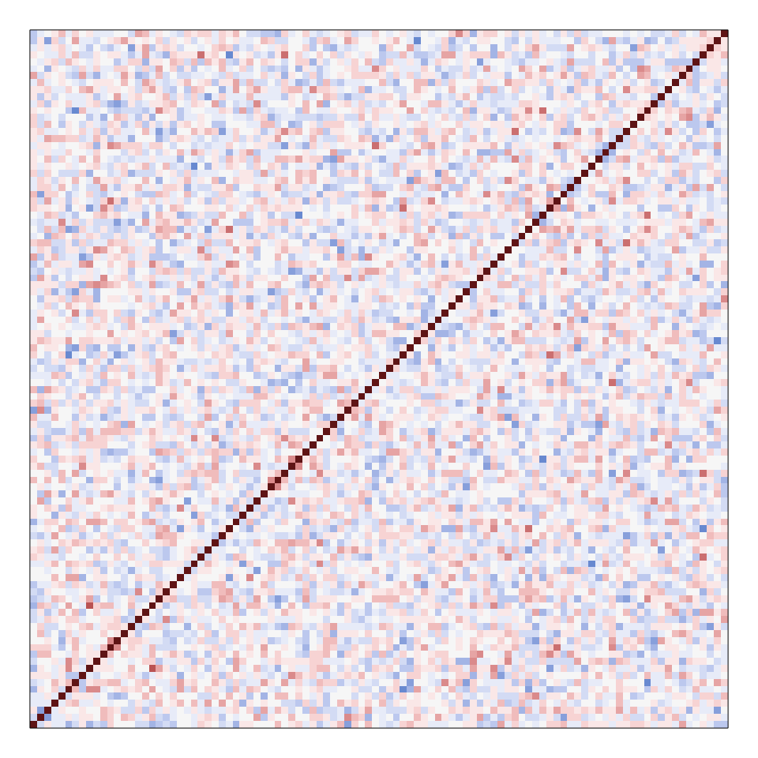

```r
par(pty = "s", mar = c(1, 1, 1, 1))
image(dummy_data$varCorr[[2]][1:100, 1:100], xaxt = "n", yaxt = "n",
      zlim = c(-1, 1), col = hcl.colors(21, "Blue-Red 3"))
```

In the matrix the color of each pixel is proportional to the correlation between two variables (blue negative, red positive). The diagonal is made up of 1s, because the correlation between each variable and itself is 1. The matrix is symmetric, since Pearson correlation is symmetric.

To look at the distribution of the correlation coefficients we only need the upper triangle of each matrix

```r
dummy_data <- dummy_data |>
  mutate(uptri = map(varCorr, \(m) m[upper.tri(m)]))
```

## The worst case: 10 samples, 1000 variables

Let’s start from the most “unfavourable” situation: 10 samples and 1000 variables

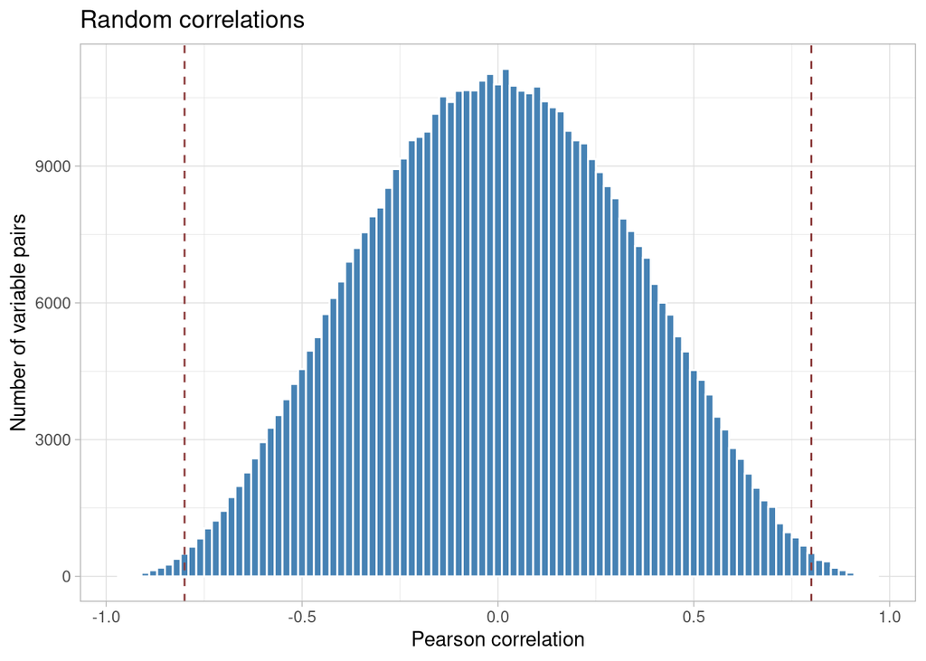

```r
tibble(r = dummy_data$uptri[[1]]) |>
  ggplot(aes(x = r)) +
  geom_histogram(binwidth = 0.02, fill = "steelblue", colour = "white") +
  geom_vline(xintercept = c(-0.8, 0.8), colour = "#8B3A3A", linetype = "dashed") +
  labs(x = "Pearson correlation", y = "Number of variable pairs", title = "Random correlations") +
  theme_light()
```

Unexpectedly ( ;-) ) … we also have variables showing high correlation! The dashed lines show the ±0.8 limits …

In absolute terms

```r
range(dummy_data$uptri[[1]])
```

```
## [1] -0.9659295  0.9601608
```

!!!!

The code below gives the indices of the pairs of variables with a correlation above 0.95 (upper triangle only, so each pair appears once and the diagonal is excluded)

```r
cor10 <- dummy_data$varCorr[[1]]
highcorrid <- which(cor10 > 0.95 & upper.tri(cor10), arr.ind = TRUE)
highcorrid
```

```
##      row col
## [1,] 198 414
## [2,] 115 702
## [3,] 744 941
```

Let’s plot the first of these pairs

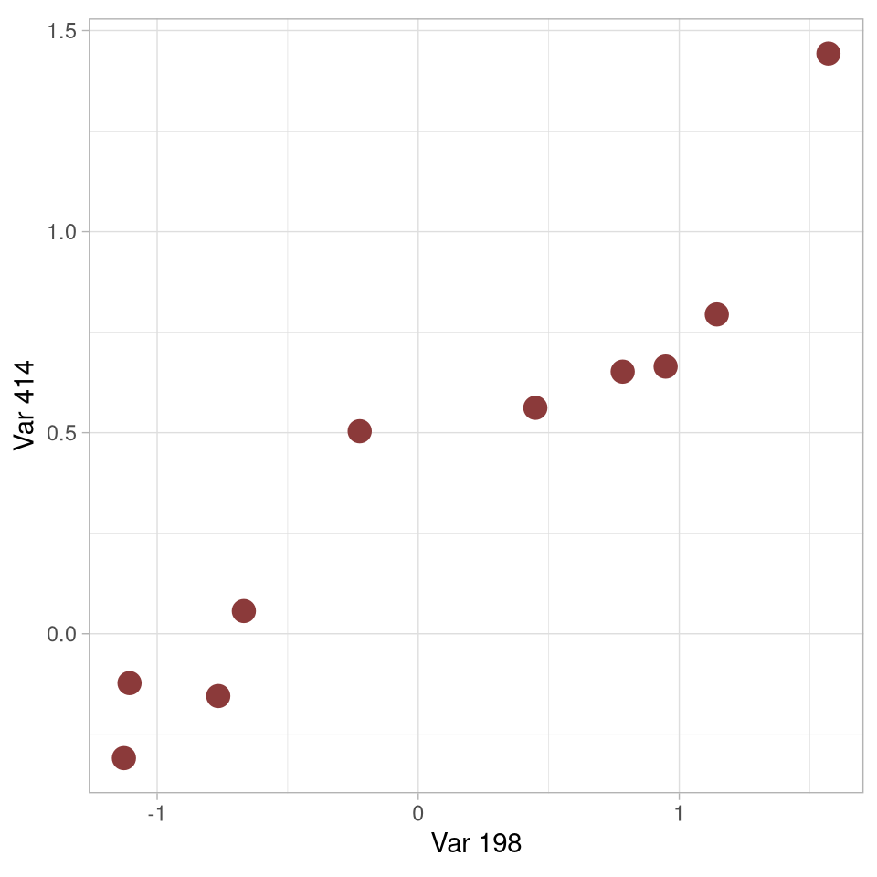

```r
v1 <- highcorrid[1, 1]
v2 <- highcorrid[1, 2]

tibble(x = dummy_data$DM[[1]][, v1], y = dummy_data$DM[[1]][, v2]) |>
  ggplot(aes(x = x, y = y)) +
  geom_point(colour = "#8B3A3A", size = 4) +
  labs(x = paste("Var", v1), y = paste("Var", v2)) +
  theme_light() +
  theme(aspect.ratio = 1)
```

Here the presence of high correlation is clear!!!

> **But this correlation does not have a “biological” origin … so it does not represent a truly scientific result …**

## Increasing the number of samples

Before giving you the chance to play with some random science, let’s look at what happens to the histogram of the correlation coefficients as the number of samples increases …

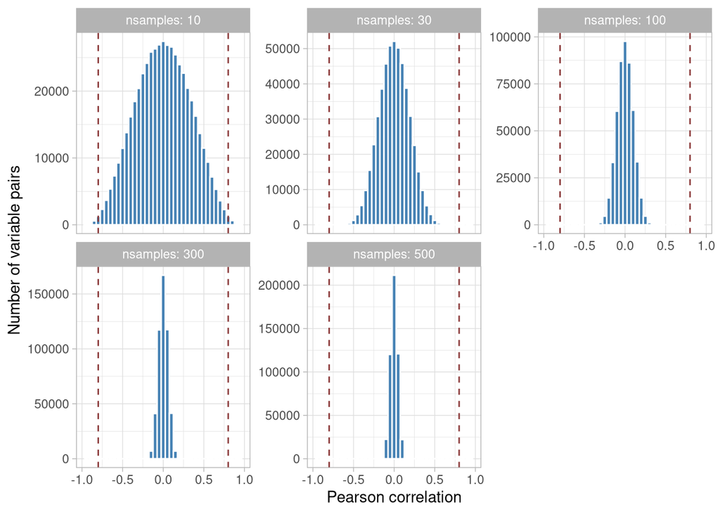

```r
dummy_data |>
  dplyr::select(nsamples, uptri) |>       ## dplyr:: because other packages also have a `select`
  unnest(uptri) |>
  ggplot(aes(x = uptri)) +
  geom_histogram(binwidth = 0.05, fill = "steelblue", colour = "white") +
  geom_vline(xintercept = c(-0.8, 0.8), colour = "#8B3A3A", linetype = "dashed") +
  facet_wrap(vars(nsamples), scales = "free_y", labeller = label_both) +
  labs(x = "Pearson correlation", y = "Number of variable pairs") +
  theme_light()
```

The probability of getting high correlation coefficients by chance decreases with the number of samples. As expected, measuring more samples gives a more realistic view of reality …

## Something for you!

1. Play around and try to understand what I did
2. Simulate an experiment where I have two classes of samples (10 treated, 10 controls) and I’m characterizing them with an array of new machines able to measure 5, 10, 100, 1000, 10000 variables. Fill each data matrix with random numbers. In each case calculate the p-value of a univariate t-test for each variable (you will have 5, 10, 100, 1000, 10000 p-values). Do you find p-values lower than 0.05? Can you plot the histograms of the p-values?

Many of the functions you need are already in the demo above.

## A possible solution

One row per “machine”, with the number of variables it measures

```r
ex2 <- tibble(nvar = c(5, 10, 100, 1000, 10000))
```

The two classes: 10 treated (`A`) and 10 controls (`B`), filled with random numbers

```r
ex2 <- ex2 |>
  mutate(A = map(nvar, \(x) matrix(rnorm(x * 10), nrow = 10)),
         B = map(nvar, \(x) matrix(rnorm(x * 10), nrow = 10)))

ex2
```

```
## # A tibble: 5 × 3
##    nvar A                   B
##   <dbl> <list>              <list>
## 1     5 <dbl [10 × 5]>      <dbl [10 × 5]>
## 2    10 <dbl [10 × 10]>     <dbl [10 × 10]>
## 3   100 <dbl [10 × 100]>    <dbl [10 × 100]>
## 4  1000 <dbl [10 × 1,000]>  <dbl [10 × 1,000]>
## 5 10000 <dbl [10 × 10,000]> <dbl [10 × 10,000]>
```

A function returning the p-value of a t-test for each column (variable)

```r
col_ttest <- function(m, n) {
  vapply(seq_len(ncol(m)), \(i) t.test(m[, i], n[, i])$p.value, numeric(1))
}
```

`map2()` is the extension of `map()` to the case where the new column combines the content of two other columns …

```r
ex2 <- ex2 |>
  mutate(ps = map2(A, B, col_ttest),
         n_signif = map_int(ps, \(p) sum(p < 0.05)))

ex2 |> dplyr::select(nvar, n_signif)
```

```
## # A tibble: 5 × 2
##    nvar n_signif
##   <dbl>    <int>
## 1     5        0
## 2    10        0
## 3   100        4
## 4  1000       48
## 5 10000      452
```

About 5% of the variables are “significant”, even if no variable is truly different between the two classes. With 10000 variables that means hundreds of false positives!

Last bit is the plot …

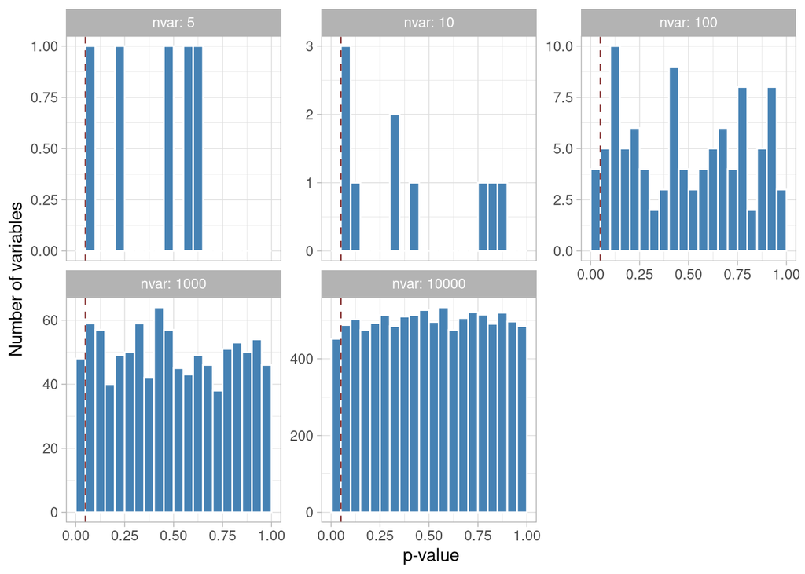

```r
ex2 |>
  dplyr::select(nvar, ps) |>
  unnest(ps) |>
  ggplot(aes(x = ps)) +
  geom_histogram(binwidth = 0.05, boundary = 0, fill = "steelblue", colour = "white") +
  geom_vline(xintercept = 0.05, colour = "#8B3A3A", linetype = "dashed") +
  facet_wrap(vars(nvar), scales = "free_y", labeller = label_both) +
  labs(x = "p-value", y = "Number of variables") +
  theme_light()
```

Under the null hypothesis the p-values are uniformly distributed: the more variables we test, the more “significant” results we get by chance.